# Model Performance Results

Zachary Katz (UNI: zak2132)

2023-02-24

# Data Import & Wrangling

```r
# Import model results

# Linear model
setwd("~/Desktop/Linear/Results/")
linear_results = list.files(path = "~/Desktop/Linear/Results/",
                            pattern = "*.csv") %>%
  map_df(~read_csv(.)) %>%
  as.data.frame() %>%
  mutate(
    scenario = as.factor(scenario),
    metal = as.factor(metal),
    time = time / 60 # time in minutes
  ) %>%
  distinct() %>%
  select(-dataset)

# Elastic net model
setwd("~/Desktop/Elastic Net/Results/")
elastic_net_results = list.files(path = "~/Desktop/Elastic Net/Results/",
                            pattern = "*.csv") %>%
  map_df(~read_csv(.)) %>%
  as.data.frame() %>%
  mutate(
    scenario = as.factor(scenario),
    metal = as.factor(metal)
  ) %>% # time already in minutes
  distinct() %>%
  select(-dataset)

# MARS model
setwd("~/Desktop/MARS/Results/")
mars_results = list.files(path = "~/Desktop/MARS/Results/",
                            pattern = "*.csv") %>%
  map_df(~read_csv(.)) %>%
  as.data.frame() %>%
  mutate(
    scenario = as.factor(scenario),
    metal = as.factor(metal)
  ) %>% # time already in minutes
  distinct() %>%
  select(-dataset)

# GAM1 model
setwd("~/Desktop/GAM1/Results/")
gam1_results = list.files(path = "~/Desktop/GAM1/Results/",
                            pattern = "*.csv") %>%
  map_df(~read_csv(.)) %>%
  as.data.frame() %>%
  mutate(
    scenario = as.factor(scenario),
    metal = as.factor(metal),
    time = time * 60 # convert to hours
  ) %>%
  distinct() %>%
  select(-dataset)

# Quantile G-Computation model
setwd("~/Desktop/Quantile G-Computation/Results/")
qgcomp_results = list.files(path = "~/Desktop/Quantile G-Computation/Results/",
                            pattern = "*.csv") %>%
  map_df(~read_csv(.)) %>%
  as.data.frame() %>%
  mutate(
    scenario = as.factor(scenario),
    metal = as.factor(metal)
  ) %>% # time already in minutes
  distinct() %>%
  select(-dataset)

# Causal Forest model
setwd("~/Desktop/Causal Forest/Results/")
causal_forest_results = list.files(path = "~/Desktop/Causal Forest/Results/",
                            pattern = "*.csv") %>%
  map_df(~read_csv(.)) %>%
  as.data.frame() %>%
  mutate(
    scenario = as.factor(scenario),
    metal = as.factor(metal)
  ) %>% # time already in minutes
  distinct() %>%
  select(-dataset)
```

```r
# Load in true effects
true_effects = readRDS("~/Desktop/Columbia MS Biostatistics/Research/Valeri lab/Practicum/true_effects.RDS")
true_effects_mixture = readRDS("~/Desktop/Columbia MS Biostatistics/Research/Valeri lab/Practicum/true_effects_mixture.RDS")
```

```r
model_performance = function(df){

  rows = data.frame()

  df = df %>%
    select(scenario:model_type)

  model_type = df$model_type[1]

  for (row_num in 1:nrow(df)){

    row = df[row_num, ]

    if (as.numeric(row$metal) %in% c(1:10)){

      true_effect = true_effects[as.numeric(row$scenario), as.numeric(row$metal) + 1]

    }

    if (as.numeric(row$metal) %in% c(11)){

      true_effect = true_effects_mixture[as.numeric(row$scenario), ][, 2]

    }

    row_truth = row %>%
      mutate(
        true_effect = as.numeric(true_effect)
      ) %>%
      mutate(
        point_bias = abs(true_effect - point_estimate),
        standard_error = (true_effect - point_estimate)^2,
        includes = if_else(CI_lower <= true_effect & CI_upper >= true_effect,
                           1,
                           0),
        CI_length = CI_upper - CI_lower,
        sig_effect = case_when(
          CI_lower > 0 & CI_upper > 0 ~ 1,
          CI_lower < 0 & CI_upper < 0 ~ 1,
          CI_lower < 0 & CI_upper > 0 ~ 0
        )
      )

    rows = rbind(rows, row_truth)

  }

  performance_summary = rows %>%
    group_by(scenario, metal) %>%
    summarize(
        mean_point_estimate = mean(point_estimate),
        true_effect = mean(true_effect),
        bias = mean(abs(point_bias)),
        relative_bias = bias / true_effect,
        relative_perc_diff = 2 * (bias - true_effect) / (abs(bias) + abs(true_effect)),
        variance_point_estimate = var(point_estimate),
        RMSE = sqrt(mean(standard_error)),
        coverage = mean(includes),
        mean_sig_effect = mean(sig_effect),
        avg_time = mean(time)
      ) %>%
    mutate(
      power = dplyr::case_when(
        metal %in% c(1, 5, 11) ~ mean_sig_effect,
        !(metal %in% c(1, 5, 11)) ~ 1 - mean_sig_effect)
    ) %>%
    select(scenario, metal, mean_point_estimate, bias, relative_bias, relative_perc_diff, variance_point_estimate, RMSE, coverage, power, avg_time)

  performance_summary$model_type = model_type

  return(performance_summary)

}
```

```r
# Check performance
linear_performance = model_performance(linear_results)
elastic_net_performance = model_performance(elastic_net_results)
mars_performance = model_performance(mars_results)
gam1_performance = model_performance(gam1_results)
qgcomp_performance = model_performance(qgcomp_results)
all_performance = rbind(linear_performance, elastic_net_performance, mars_performance, gam1_performance, qgcomp_performance)
```

# Model Performance Viz

- Scenario 1: baseline (simple exposures, simple confounding)
- Scenario 2: complex exposures (nonlinear / interactions), simple confounding
- Scenario 3: complex exposures (nonlinear / interactions) + multicollinearity, simple confounding
- Scenario 4: complex exposures (trigonometric), simple confounding
- Scenario 5: complex exposures (trigonometric) + multicollinearity, simple confounding
- Scenario 6: simple exposures, complex confounding
- Scenario 7: complex exposures (nonlinear / interactions), complex confounding
- Scenario 8: complex exposures (trigonometric), complex confounding
- Scenario 9: complex exposures (nonlinear / interactions) + multicollinearity, complex confounding
- Scenario 10: complex exposures (trigonometric) + multicollinearity, complex confounding

Note: besides confounders, only exposure metals 1 and 5 are specified in the functional form for each scenario. “Metal” 11 is the complete metal mixture.

## Relative Bias

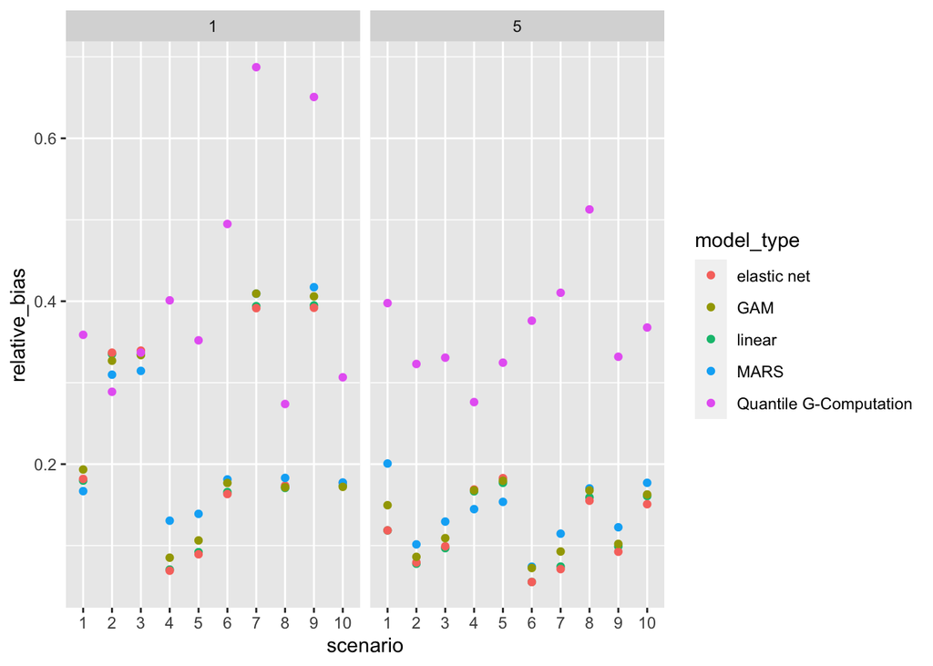

```r
all_performance %>%
  filter(metal %in% c(1,5)) %>%
  ggplot(aes(x = scenario, y = relative_bias, color = model_type)) +
  geom_point() +
  facet_grid(. ~ metal)
```

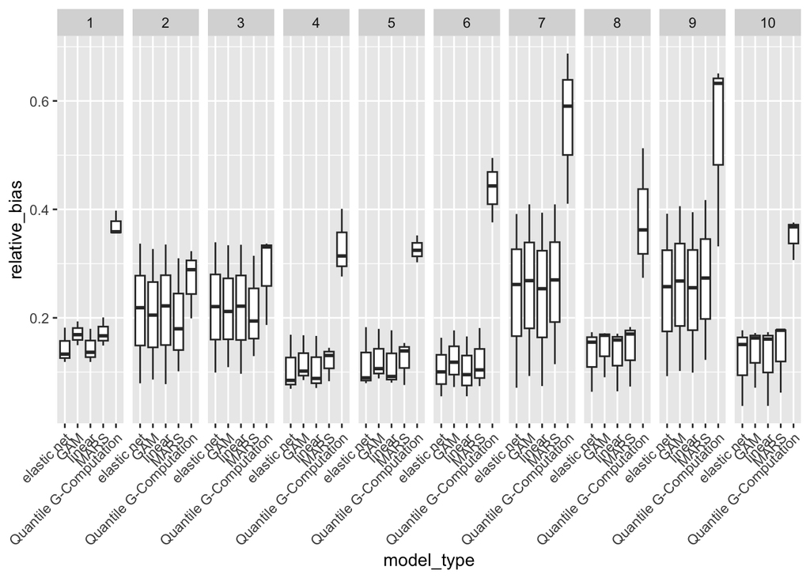

```r
# Explorations of relative bias by scenario, all metals and models
all_performance %>%
  ggplot(aes(x = model_type, y = relative_bias)) +
  geom_boxplot() +
  facet_grid(. ~ scenario) +
  theme(axis.text.x = element_text(angle = 45, vjust = 1, hjust = 1))
```

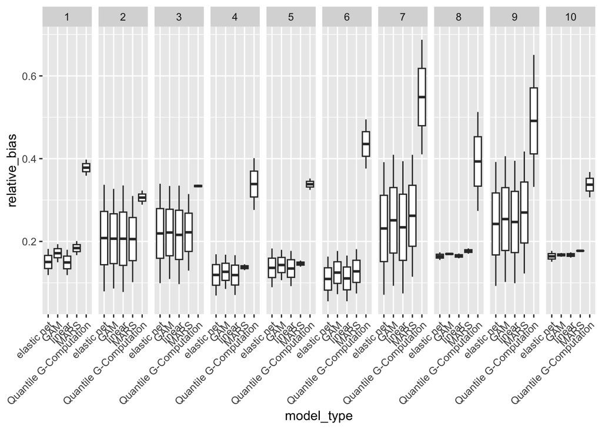

```r
# Explorations of relative bias by scenario, only metals 1 and 5 (all models)
all_performance %>%
  filter(metal %in% c(1, 5)) %>%
  ggplot(aes(x = model_type, y = relative_bias)) +
  geom_boxplot() +
  facet_grid(. ~ scenario) +
  theme(axis.text.x = element_text(angle = 45, vjust = 1, hjust = 1))
```

Observations: * In general, lowest bias seen for scenarios 4, 5, and 6; moderate bias seen for scenarios 1, 8, and 10; higher bias seen for scenarios 2, 3, 7, and 9 * Quantile G-Computation seems to have much higher bias in all scenarios * Relative bias lower for elastic net and linear models in most scenarios

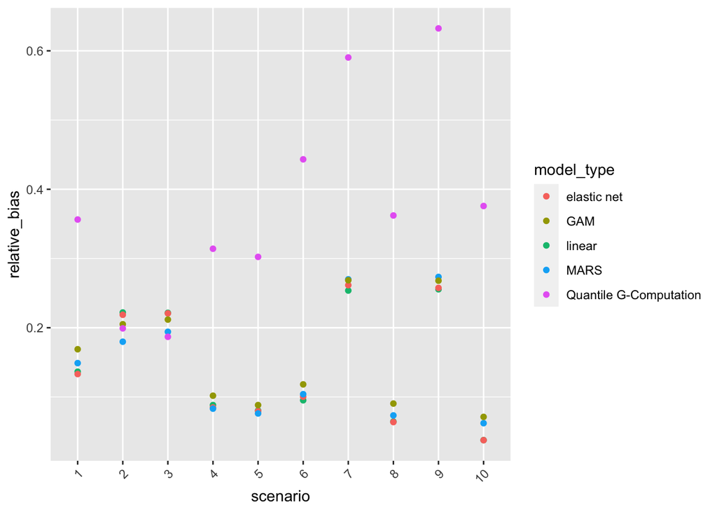

```r
# Explorations of relative bias by scenario, metal mixture only
all_performance %>%
  filter(metal == 11) %>%
  ggplot(aes(x = scenario, y = relative_bias, color = model_type)) +
  geom_point() +
  theme(axis.text.x = element_text(angle = 45, vjust = 1, hjust = 1))
```

Observations: * Again, quantile g-computation has high bias across most scenarios * Lower bias in scenarios 4, 5, 6, 8, and 10, but higher bias in scenarios 1, 2, 3, 7, and 9 * Linear and elastic net models perform better than expected in many cases, whereas GAM in particular tends to perform worse

## RMSE

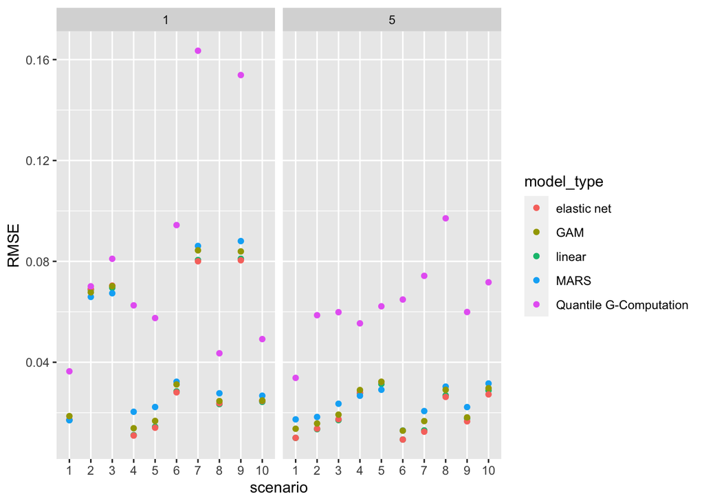

```r
all_performance %>%
  filter(metal %in% c(1,5)) %>%
  ggplot(aes(x = scenario, y = RMSE, color = model_type)) +
  geom_point() +
  facet_grid(. ~ metal)
```

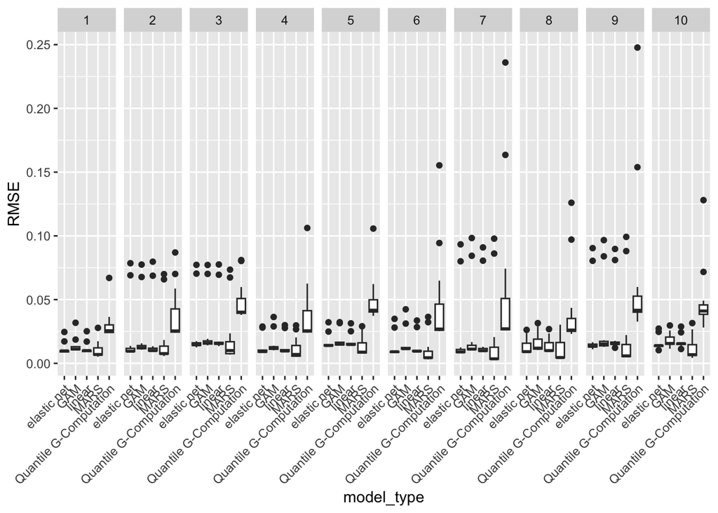

```r
# Explorations of relative bias by scenario, all metals and models
all_performance %>%
  ggplot(aes(x = model_type, y = RMSE)) +
  geom_boxplot() +
  facet_grid(. ~ scenario) +
  theme(axis.text.x = element_text(angle = 45, vjust = 1, hjust = 1))
```

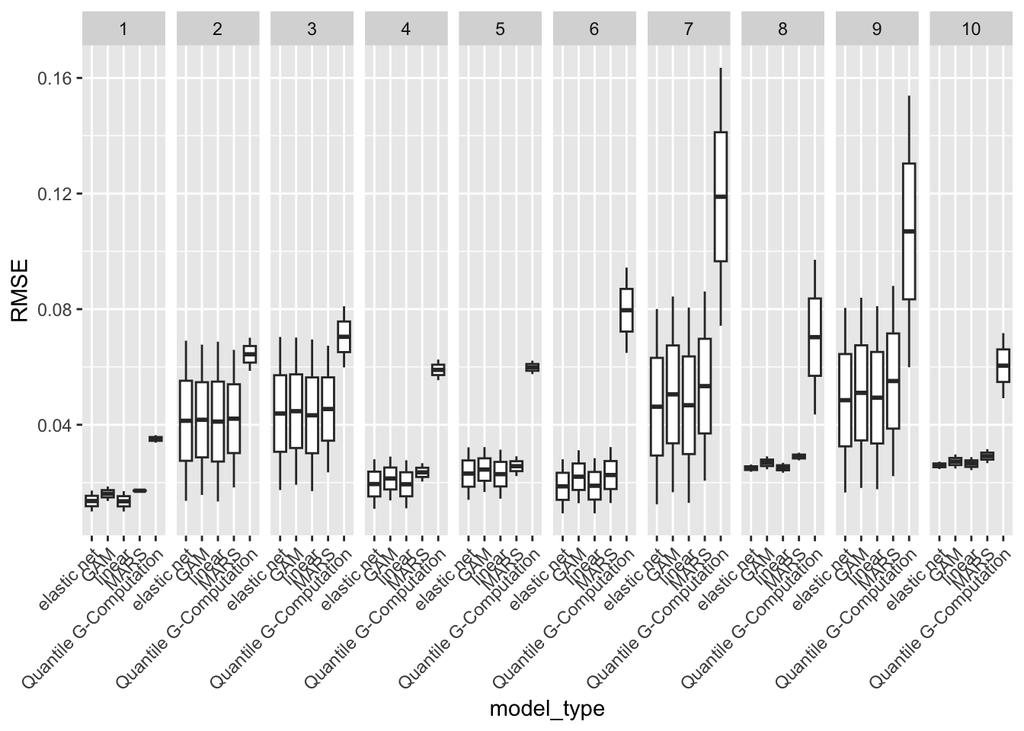

```r
# Explorations of relative bias by scenario, only metals 1 and 5 (all models)
all_performance %>%
  filter(metal %in% c(1, 5)) %>%
  ggplot(aes(x = model_type, y = RMSE)) +
  geom_boxplot() +
  facet_grid(. ~ scenario) +
  theme(axis.text.x = element_text(angle = 45, vjust = 1, hjust = 1))
```

Observations: * In general, lowest RMSE seen for scenarios 1, 4, 5, and 6; moderate RMSE seen for scenarios 8 and 10; higher RMSE seen for scenarios 2, 3, 7, and 9 * Quantile G-Computation seems to have much higher RMSE in all scenarios * RMSE slightly lower for elastic net and linear models in most scenarios

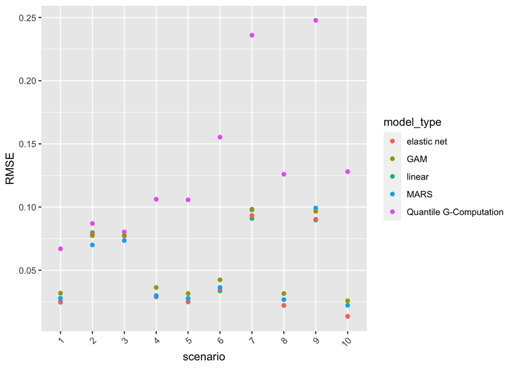

```r
# Explorations of relative bias by scenario, metal mixture only
all_performance %>%
  filter(metal == 11) %>%
  ggplot(aes(x = scenario, y = RMSE, color = model_type)) +
  geom_point() +
  theme(axis.text.x = element_text(angle = 45, vjust = 1, hjust = 1))
```

Observations: * Again, quantile g-computation has high RMSE across most scenarios * Lower RMSE in scenarios 1, 4, 5, 6, 8, and 10, but higher RMSE in scenarios 2, 3, 7, and 9 * Linear and elastic net models perform better than expected in many cases, whereas GAM in particular tends to perform worse